# phsstyles

[figure not shown]

## Overview

The functions made available in this package include:

- `phs_colours()` returns hex value for specific named colours
- `theme_phs()` apply pre-defined PHS theme for charts
- `scale_colour_discrete_phs()` apply discrete PHS colour scales for charts
- `scale_colour_continuous_phs()` apply continuous PHS colour scales for charts
- `scale_fill_discrete_phs()` apply discrete PHS colour filling scales for charts
- `scale_fill_continuous_phs()` apply continuous PHS colour filling scales for charts

### Colour palettes

The PHS Brand Identity Guidelines provide corporate colour palettes, namely “main” and “supporting”, with eight overall colours available:

- **Main colour palette**: PHS purple, PHS magenta, PHS blue, and PHS green
- **Supporting colour palette**: PHS graphite, PHS teal, PHS liberty, and PHS rust

The guidelines also include recommendations, such as:

- “PHS purple should not be used for text because there is a danger the text will be mistaken for a visited link”
- “PHS green should not be used for text against a white background as the contrast ratio is too low”
- “Tints and tones of the corporate colours can be used for borders, backgrounds and hover states of buttons and links”

Within {phsstyles}, the palettes are available individually, as `main` or `supporting`, or combined in the `all` palette.

*Hint: the colour names and hex values can be copied by clicking on them in the tables below.*

#### `all`

The `all` palette is made up of both the `main` and `supporting` palettes as below.

#### `main`

| Name | Hex | Swatch |
| --- | --- | --- |
| phs-purpleCopied! | #3F3685Copied! |  |
| phs-magentaCopied! | #9B4393Copied! |  |
| phs-blueCopied! | #0078D4Copied! |  |
| phs-greenCopied! | #83BB26Copied! |  |

#### `supporting`

| Name | Hex | Swatch |
| --- | --- | --- |
| phs-graphiteCopied! | #948DA3Copied! |  |
| phs-tealCopied! | #1E7F84Copied! |  |
| phs-libertyCopied! | #6B5C85Copied! |  |
| phs-rustCopied! | #C73918Copied! |  |

### Gradient palettes

Each colour is also available as a gradient palette, providing suitable gradient tints set at 100%, 80%, 50%, 30%, and 10%.

#### `main-purples`

| Name | Hex | Swatch |
| --- | --- | --- |
| phs-purpleCopied! | #3F3685Copied! |  |
| phs-purple-80Copied! | #655E9DCopied! |  |
| phs-purple-50Copied! | #9F9BC2Copied! |  |
| phs-purple-30Copied! | #C5C3DACopied! |  |
| phs-purple-10Copied! | #ECEBF3Copied! |  |

#### `main-magentas`

| Name | Hex | Swatch |
| --- | --- | --- |
| phs-magentaCopied! | #9B4393Copied! |  |
| phs-magenta-80Copied! | #AF69A9Copied! |  |
| phs-magenta-50Copied! | #CDA1C9Copied! |  |
| phs-magenta-30Copied! | #E1C7DFCopied! |  |
| phs-magenta-10Copied! | #F5ECF4Copied! |  |

#### `main-blues`

| Name | Hex | Swatch |
| --- | --- | --- |
| phs-blueCopied! | #0078D4Copied! |  |
| phs-blue-80Copied! | #3393DDCopied! |  |
| phs-blue-50Copied! | #80BCEACopied! |  |
| phs-blue-30Copied! | #B3D7F2Copied! |  |
| phs-blue-10Copied! | #E6F2FBCopied! |  |

#### `main-greens`

| Name | Hex | Swatch |
| --- | --- | --- |
| phs-greenCopied! | #83BB26Copied! |  |
| phs-green-80Copied! | #9CC951Copied! |  |
| phs-green-50Copied! | #C1DD93Copied! |  |
| phs-green-30Copied! | #DAEBBECopied! |  |
| phs-green-10Copied! | #F3F8E9Copied! |  |

#### `supporting-graphites`

| Name | Hex | Swatch |
| --- | --- | --- |
| phs-graphiteCopied! | #948DA3Copied! |  |
| phs-graphite-80Copied! | #A9A4B5Copied! |  |
| phs-graphite-50Copied! | #CAC6D1Copied! |  |
| phs-graphite-30Copied! | #DFDDE3Copied! |  |
| phs-graphite-10Copied! | #F4F4F6Copied! |  |

#### `supporting-teals`

| Name | Hex | Swatch |
| --- | --- | --- |
| phs-tealCopied! | #1E7F84Copied! |  |
| phs-teal-80Copied! | #4B999DCopied! |  |
| phs-teal-50Copied! | #8FBFC2Copied! |  |
| phs-teal-30Copied! | #BCD9DACopied! |  |
| phs-teal-10Copied! | #E9F2F3Copied! |  |

#### `supporting-liberties`

| Name | Hex | Swatch |
| --- | --- | --- |
| phs-libertyCopied! | #6B5C85Copied! |  |
| phs-liberty-80Copied! | #897D9DCopied! |  |
| phs-liberty-50Copied! | #B5AEC2Copied! |  |
| phs-liberty-30Copied! | #D3CEDACopied! |  |
| phs-liberty-10Copied! | #F0EFF3Copied! |  |

#### `supporting-rusts`

| Name | Hex | Swatch |
| --- | --- | --- |
| phs-rustCopied! | #C73918Copied! |  |
| phs-rust-80Copied! | #D26146Copied! |  |
| phs-rust-50Copied! | #E39C8CCopied! |  |
| phs-rust-30Copied! | #EEC4BACopied! |  |
| phs-rust-10Copied! | #F9EBE8Copied! |  |

## Installation

Users within PHS, using Posit Workbench, are able to install {phsstyles} like any other package as the package is made available on the PHS Posit Package Manager.

```r
install.packages("phsstyles")
```

Outside of the above use case, {phsstyles} can be installed directly from GitHub using {remotes} with:

```r
remotes::install_github("Public-Health-Scotland/phsstyles")
```

Where network security settings prevent `remotes::install_github()` from working, {phsstyles} can be installed by downloading the [zip of the repository](https://github.com/Public-Health-Scotland/phsstyles/archive/master.zip) and running the following code (replacing the section marked `<>`, including the arrows themselves, with the location of the downloaded file):

```r
remotes::install_local(
  "<FILEPATH OF ZIPPED FILE>/phsstyles-master.zip",
  upgrade = "never"
)
```

## Using phsstyles

Load {phsstyles} using `library()`:

```r
library(phsstyles)
```

To access the help file for a {phsstyles} function, type `?function_name` into the RStudio console after loading the package:

```r
?phs_colours
```

### phs_colours

Returns hex value(s) for specific named PHS colours.

```r
# Generate hex code for those colours
phs_colours(c("phs-blue", "phs-purple"))
```

```
#> [1] "#0078D4" "#3F3685"
```

```r
# List hex code for all the available colours
phs_colours()
```

```
#>      phs-purple     phs-magenta        phs-blue       phs-green    phs-graphite
#>       "#3F3685"       "#9B4393"       "#0078D4"       "#83BB26"       "#948DA3"
#>        phs-teal     phs-liberty        phs-rust   phs-purple-80   phs-purple-50
#>       "#1E7F84"       "#6B5C85"       "#C73918"       "#655E9D"       "#9F9BC2"
#>   phs-purple-30   phs-purple-10  phs-magenta-80  phs-magenta-50  phs-magenta-30
#>       "#C5C3DA"       "#ECEBF3"       "#AF69A9"       "#CDA1C9"       "#E1C7DF"
#>  phs-magenta-10     phs-blue-80     phs-blue-50     phs-blue-30     phs-blue-10
#>       "#F5ECF4"       "#3393DD"       "#80BCEA"       "#B3D7F2"       "#E6F2FB"
#>    phs-green-80    phs-green-50    phs-green-30    phs-green-10 phs-graphite-80
#>       "#9CC951"       "#C1DD93"       "#DAEBBE"       "#F3F8E9"       "#A9A4B5"
#> phs-graphite-50 phs-graphite-30 phs-graphite-10     phs-teal-80     phs-teal-50
#>       "#CAC6D1"       "#DFDDE3"       "#F4F4F6"       "#4B999D"       "#8FBFC2"
#>     phs-teal-30     phs-teal-10  phs-liberty-80  phs-liberty-50  phs-liberty-30
#>       "#BCD9DA"       "#E9F2F3"       "#897D9D"       "#B5AEC2"       "#D3CEDA"
#>  phs-liberty-10     phs-rust-80     phs-rust-50     phs-rust-30     phs-rust-10
#>       "#F0EFF3"       "#D26146"       "#E39C8C"       "#EEC4BA"       "#F9EBE8"
```

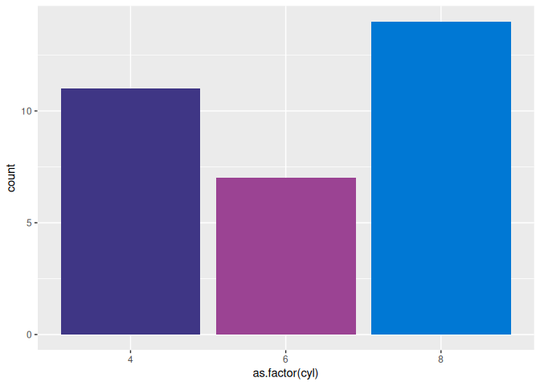

```r
# Create a ggplot chart using this function
library(ggplot2)
phs_bar_chart <- ggplot(mtcars, aes(x = as.factor(cyl), fill = as.factor(cyl))) +
  geom_bar() +
  scale_fill_manual(values = phs_colours(c("phs-purple", "phs-magenta", "phs-blue"))) +
  theme(legend.position = "none")

phs_bar_chart
```

### theme_phs

Applies the PHS standard theme to a {ggplot2} graphic.

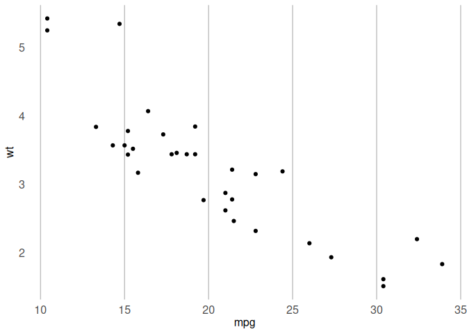

```r
library(ggplot2)
# Apply PHS theme to a chart
qplot(mpg, wt, data = mtcars) + theme_phs()
```

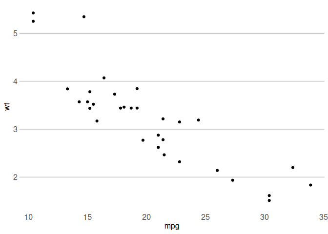

```r
# Overwirte a feature (e.g. remove vertical gridlines and add horizontal ones)
qplot(mpg, wt, data = mtcars) + theme_phs() +
  theme(panel.grid.major.x = element_blank(),
        panel.grid.major.y = element_line(colour =
                                            grDevices::rgb(190 / 255,
                                                           190 / 255,
                                                           190 / 255)))
```

### scale_colour_discrete_phs

Applies a discrete PHS colour scale to objects that take colour (e.g. lines).

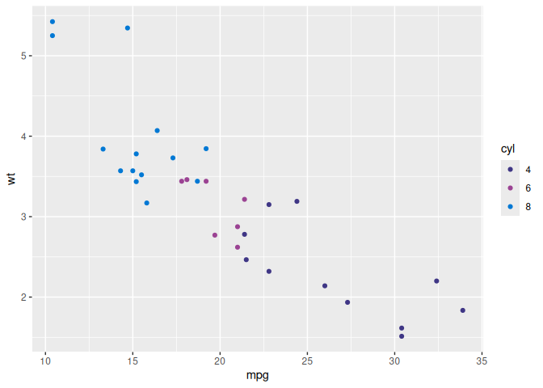

```r
# Create a scatter plot using PHS main colour palette
library(ggplot2)
df <- mtcars
df[,'cyl'] <- as.factor(df[,'cyl'])
qplot(mpg, wt, data = df, colour = cyl) +
  scale_colour_discrete_phs(palette = "main")
```

### scale_fill_discrete_phs

Applies a discrete PHS colour scale to objects that take fill (e.g. bars).

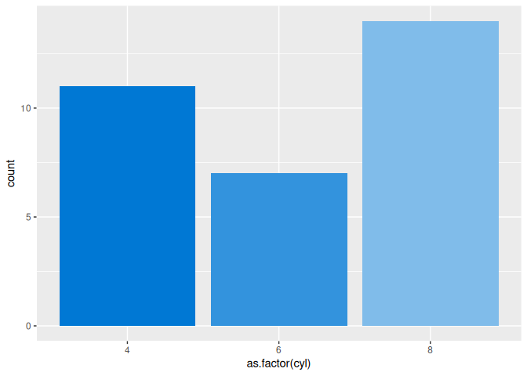

```r
# Create a bar chart filled with colours from PHS main-blues palette
library(ggplot2)
ggplot(mtcars, aes(x = as.factor(cyl), fill = as.factor(cyl))) +
  geom_bar() +
  scale_fill_discrete_phs(palette = "main-blues") +
  theme(legend.position = "none")
```

### scale_colour_continuous_phs

Applies a continuous PHS colour scale to objects that take colour (e.g. lines).

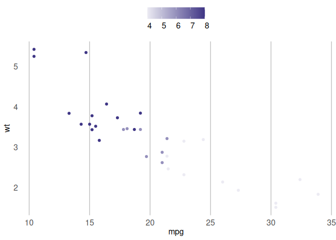

```r
# Create a scatter plot using continuous colours from PHS main-purples palette
library(ggplot2)
qplot(mpg, wt, data = mtcars, colour = cyl) +
  scale_colour_continuous_phs(palette = "main-purples") +
  theme_phs()
```

### scale_fill_continuous_phs

Applies a continuous PHS colour scale to objects that take fill (e.g. bars).

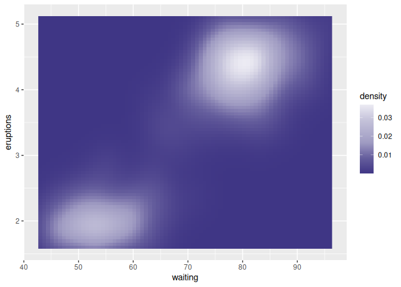

```r
# Create a raster chart filled with reversed continuous colours from PHS
# main-purples palette
library(ggplot2)
ggplot(faithfuld, aes(waiting, eruptions)) +
  geom_raster(aes(fill = density)) +
  scale_fill_continuous_phs(palette = "main-purples", direction = -1)
```

## Contributing to phsstyles

This package is currently maintained by [Tina Fu](https://github.com/Tina815).

This package is intended to be in continuous development and contributions may be made by anyone within PHS. If you would like to make a contribution, please first create an [issue](https://github.com/Public-Health-Scotland/phsstyles/issues) on GitHub and assign **all** of the package maintainers to it. This is to ensure that no duplication of effort occurs in the case of multiple people having the same idea. The package maintainers will discuss the issue and get back to you as soon as possible.

While the most obvious and eye catching (as well as intimidating) way of contributing is by writing a function, this isn’t the only way to make a useful contribution. Fixing typos in documentation, for example, isn’t the most glamorous way to contribute, but is of great help to the package maintainers. Please see this [blogpost by Jim Hester](https://www.tidyverse.org/blog/2017/08/contributing/) for more information on getting started with contributing to open source software.

When contributing, please create a [branch](https://github.com/Public-Health-Scotland/phsstyles/branches) in this repository and carry out all work on it. Please ensure you have linked RStudio to your GitHub account using `usethis::edit_git_config()` prior to making your contribution. When you are ready for a review, please create a [pull request](https://github.com/Public-Health-Scotland/phsstyles/pulls) and assign **all** of the package maintainers as reviewers. One or all of them will conduct a review, provide feedback and, if necessary, request changes prior to merging your branch.

Please be mindful of information governance when contributing to this package. No data files (aside from publicly available and downloadable datasets or unless explicitly approved), server connection details, passwords or person identifiable or otherwise confidential information should be included anywhere within this package or any other repository (whether public or private) used within PHS. This includes within code and code commentary. For more information on security when using git and GitHub and general guidance, please see the [Github Guidance](https://public-health-scotland.github.io/knowledge-base/docs/Version%20Control?doc=GitHub%20Guidance.md) available on the Data Science Knowledge Base. For general support and getting started with git and GitHub for version control, the Data Science Knowledge Base has other materials, including the [Git guide](https://Public-Health-Scotland.github.io/git-guide/).

When contributing, please feel free to add yourself to the ‘Authors’ section of the `Description` file. As a rule of thumb, please assign your role as author (`"aut"`) when writing an exported function, and as contributor (`"ctb"`) for anything else.

{phsstyles} will, as much as possible, adhere to the [tidyverse style guide](https://style.tidyverse.org/) and the [rOpenSci package development guide](https://devguide.ropensci.org/). The most pertinent points to take from these are:

- All function names should be in lower case, with words separated by an underscore (snake_case)
- Put a space after a comma, never before
- Put a space before and after infix operators such as `<-`, `==` and `+`
- Limit code to 80 characters per line
- Function documentation should be generated using [`roxygen2`](https://github.com/r-lib/roxygen2)
- Functions should be tested using [`testthat`](https://github.com/r-lib/testthat) where possible
- The package should always pass `devtools::check()`

It’s not necessary to have experience with GitHub or of building an R package to contribute to `phsstyles`. If you wish to contribute code then, as long as you can write an R function, the package maintainers can assist with error handling, writing documentation, testing and other aspects of package development. It is advised, however, to consult [Hadley Wickham’s R Packages book](https://r-pkgs.org/) prior to making a contribution. It may also be useful to consult the [documentation](https://github.com/Public-Health-Scotland/phsstyles/tree/master/R) and [tests](https://github.com/Public-Health-Scotland/phsstyles/tree/master/tests/testthat) of existing functions within this package as a point of reference.

Please note that this README may fail to ‘Knit’ at times as a result of network security settings. This will likely be due to the badges for the package’s release version, continuous integration status and test coverage at the top of the document. If you are editing the `README.Rmd` document and are unable to successfully get it to ‘Knit’, please contact the package maintainers for assistance.